# Capstone project Nils Brun 2024

Nils Brun

2024-05-23

# Introduction

This Project aimed to understand and analyze the bias in the media coverage of conflict happening in gaza. Using the swissdox API of the LiRi (Linguistic Research Infrastructure) of the University of Zurich, i got access to the data of the SRF (Schweizer Radio und Fernsehen) news articles in the time frame of the 7. october 2023 to the 21. may 2024. The specific time frame was chosen, due to the attacks of Hamas on Israel at the beginning of this new stage of the conflict.

# Hypothesis

The hypothesis of this project suggests, that the media coverage is not only slanted towards more visibility for the israeli side, but also that the media coverage is biased in the way that it is more likely to use negative words when talking about the palestinian side.

Therefore the hypothesis of this short capstoneproject are the following: 1. The media coverage of SRF gives more visibility to the israeli side 2. The media coverage of SRF is negatively slanted towards the palestinian side

# Data gathering, preparation and plotting

## Data gathering

Unfortunately the documentation of the API was only for python. While my attempts on translating the code to R were not successful (this can be seen in the junk folder), i decided to use a jupiter notebook with python to gather the data. The data was then saved as a tsv file and loaded into R. The jupiter notebook can be found in the data folder.

## Data preparation

```r
#load data
library(readr)
data_srf <- read_tsv("../data/dataset.tsv")

#make the "head" and "content" column lowercase
data_srf$head_lower <- tolower(data_srf$head)
data_srf$content_lower <- tolower(data_srf$content)

#change the formate of the pubtime variable
data_srf$pubtime <- as.Date(data_srf$pubtime)

#Load the stringr package
library(stringr)

#Count the occurrences of "hamas" in each entry of the "head" and "content" column, case insensitive
data_srf$head_count_hamas <- str_count(tolower(data_srf$head), "hamas")
data_srf$content_count_hamas <- str_count(tolower(data_srf$content), "hamas")

#Count the occurrences of "israel" in each entry of the "head" and "content" column, case insensitive
data_srf$head_count_israel <- str_count(tolower(data_srf$head), "israel")
data_srf$content_count_israel <- str_count(tolower(data_srf$content), "israel")

#change all "ä" to "ae" in the "head" and "content" column
data_srf$head <- str_replace_all(data_srf$head, "\u00e4", "ae")
data_srf$content <- str_replace_all(data_srf$content, "\u00e4", "ae")
#Count the occurrence of "Palästina" in each entry of the "head" and "content column, case insensitive
data_srf$head_count_palaestina <- str_count(tolower(data_srf$head), "palaestina")
data_srf$content_count_palaestina <- str_count(tolower(data_srf$content), "palaestina")

#Count the occurrence of "Gaza" in each entry of the "head" and "content column, case insensitive
data_srf$head_count_gaza <- str_count(tolower(data_srf$head), "gaza")
data_srf$content_count_gaza <- str_count(tolower(data_srf$content), "gaza")

#Count the occurence of "Genozid" in each entry of the "head" and "content" column, case insensitive
data_srf$head_count_genozid <- str_count(tolower(data_srf$head), "genozid")
data_srf$content_count_genozid <- str_count(tolower(data_srf$content), "genozid")

#Count the occurence of "Krieg" in each entry of the "head" and "content" column, case insensitive
data_srf$head_count_krieg <- str_count(tolower(data_srf$head), "krieg")
data_srf$content_count_krieg <- str_count(tolower(data_srf$content), "krieg")

#Count the occurence of "Terrorismus" in each entry of the "head" and "content" column, case insensitive
data_srf$head_count_terrorismus <- str_count(tolower(data_srf$head), "terrorismus")
data_srf$content_count_terrorismus <- str_count(tolower(data_srf$content), "terrorismus")

#save preped data
write_tsv(data_srf, "../data_prep/data_srf_prep.tsv")
```

## Data plotting

While I did some additional plots in the main.Rmd file, there will only be the more significant plots in this report.

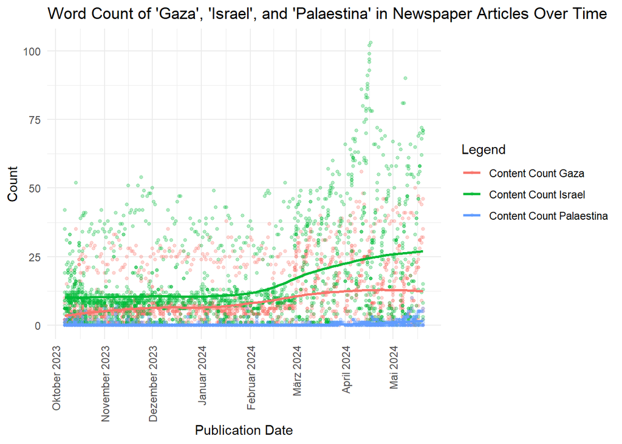

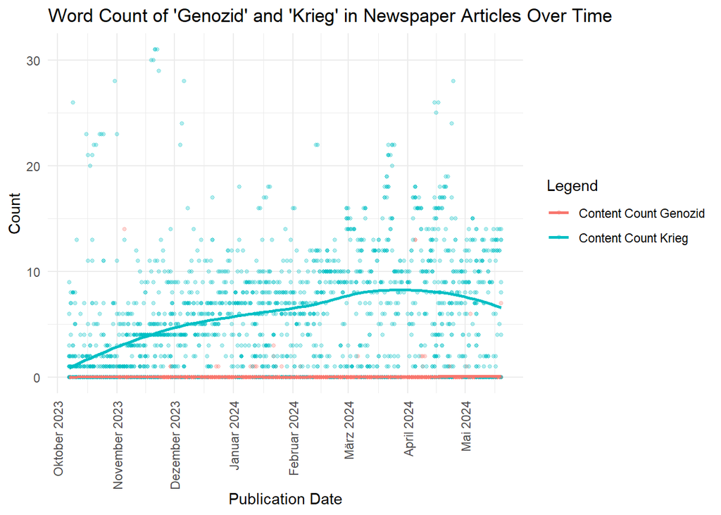

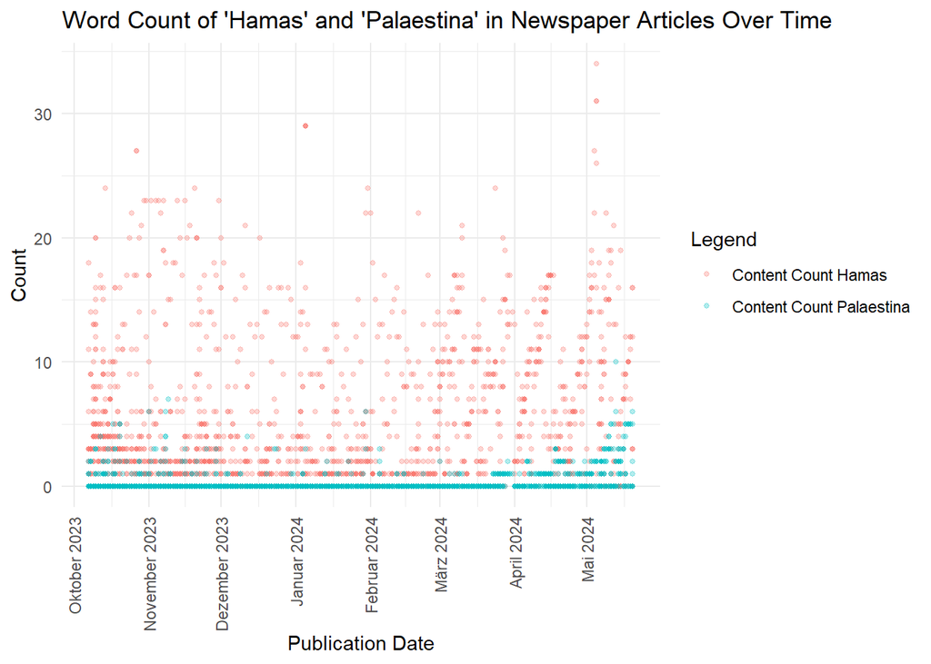

# Discussion

The first plot is a word count of the three words “Gaza”, “Palästina” and “Israel”. Allthough it would be hard to make a conclusion on the media coverage of both of the sides on only this plot, it is interesting to see that Israel gets consistently more mentioned than Gaza and Palästina. This might imply that the media coverage is more focused on the israeli side. There is definitely more research necessary to make a definite conclusion on this.

The second and thrid plot both aim to investigate a portrayal bias in the media coverage. The second plot shows the word count of “Genozid” and “Krieg”. While the word “Genozid” is used very rarely, the word “Krieg” is used more often. This is especially interesting since multiple international organisations have stated that this conflict is to be considered a genocide of the palestinian people.

The third plot shows the word count of “Hamas” and “Palästina”. While Hamas is the terror organisation, palestine is the national state of the palestinian people. Even if hamas is the military force of the palistinian nation, it deligitimizes the palestinian cause to live free and have their own state.

# Conclusion

While the focus on this project was on the data gathering, preparation and evaluation it still shows some interesting results. Even if those results may be right (as much as I think they are) it is important that this analysis is not nearly scientific enough. For this reason it would make sence to further investigate the data, use a bigger dataset and more sophisticated methods of evaluation.